# Análisis descriptivo de victimas por accidentes de tráfico en inglaterra y la aplicación del Modelo GLM(Poisson)

Análisis descriptivo de victimas por accidentes de tráfico

William David Ibica P

2026-02-23

# Introducción

## Descripción del Conjunto de Datos

Este análisis utiliza el conjunto de datos de accidentes de tráfico del Reino Unido, que contiene más de 1.504.150 millones de registros de accidentes con 33 características que incluyen:

- Ubicación geográfica (Longitud, Latitud)
- Gravedad del accidente (Fatal, Serio, Leve)
- Número de vehículos involucrados
- **Número de víctimas (Variable respuesta principal)**
- Condiciones de luz
- Condiciones meteorológicas
- Condiciones de la superficie de la carretera
- Tipo de área (Urbana/Rural)
- Límite de velocidad
- Año del accidente (2005-2014)

## Objetivos del Análisis

### Objetivo General

Que factores influyen en el número de víctimas en accidentes de tráfico, utilizando diversas técnicas estadísticas y de modelamiento.

### Objetivos Específicos

1. **Modelamiento Poisson**: Construir modelos de regresión Poisson para predecir el número de víctimas, incluyendo modelos con y sin offset.

# 2. Preguntas de Investigación

**P1**: ¿Cómo influye el número de vehículos involucrados en el número de víctimas de un accidente?

**P2**: ¿Existen diferencias significativas en el número de víctimas entre accidentes en zonas urbanas y rurales?

**P3**: ¿Cómo cambia la interpretación del modelo cuando se utiliza un offset para modelar la **tasa** de víctimas por vehículo?

El uso de un offset en el modelo Poisson (o Quasi-Poisson) cambia fundamentalmente la interpretación: ya no modelamos el número absoluto de víctimas, sino la tasa de víctimas por vehículo involucrado. # Análisis Exploratorio de Datos (EDA)

Para el análisis respectivo, se tomo una muestra de la población con un total de $100.000$ registros escogidos al azar con la intención de optimizar los resultados sin perder poder estadístico. Todo esto se emplea después de realizar respectivos ajustes a la base de datos.

## Limpieza de datos

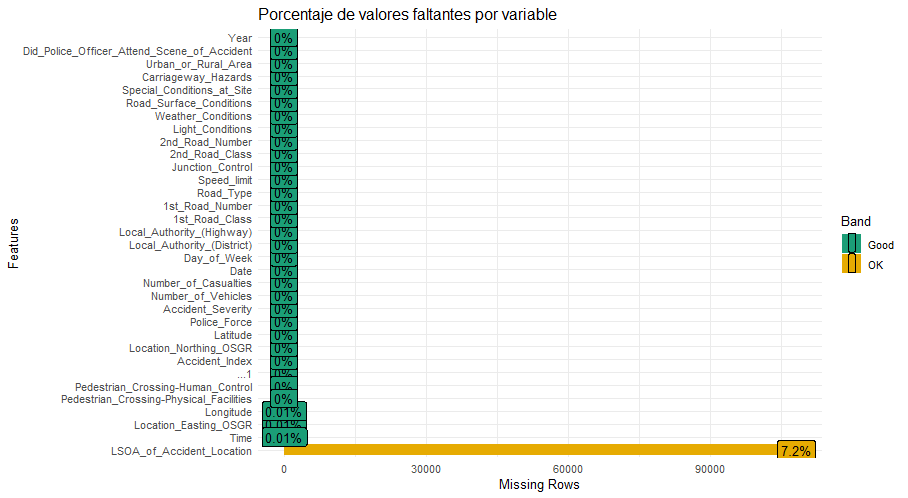

Se observa que las variables que presentan **NA** son “*Longitude*”, “*Localización_Easting_OSGR*”, “*Time*” y “*LSOA_of_Accident_location*”, de la cuál, las tres primera tienen aproximadamente un $0.01 \%$ de datos vacíos y la restante presenta un $7.2 \%$. Se toma la decisión de aplicar la eliminación de dichos NA para obtener una base mas solida, dando así un total de 1.395.848 millones de datos, en la cuál, se eliminaron 108.302 registros.

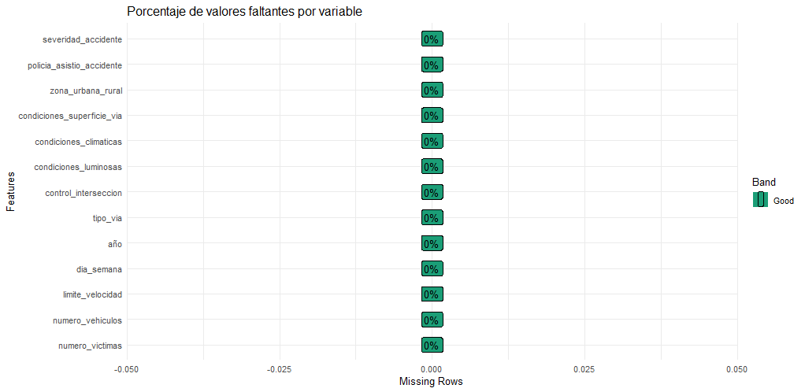

se evidencia que la base de datos no presenta ningún porcentaje de NA, además, se realizo el re nombramiento de las variables para un mejor entendimiento y la selección de aquellas para el análisis e implementación del modelo GLM POISSON.

A continuación, se presentan resúmenes estadísticos del número de víctimas comparada por diferentes covariables:

|  | tipo_via | numero_victimas.mean | numero_victimas.sd | numero_victimas.median | numero_victimas.min | numero_victimas.max | numero_victimas.IQR | numero_victimas.length | numero_victimas.coef_variacion |
| --- | --- | --- | --- | --- | --- | --- | --- | --- | --- |
| 1 | Doble calzada | 1.495 | 1.025 | 1 | 1 | 42 | 1 | 14992 | 68.544 |
| 2 | Calle de una vía | 1.192 | 0.584 | 1 | 1 | 7 | 0 | 2043 | 48.942 |
| 3 | Glorieta | 1.256 | 0.627 | 1 | 1 | 11 | 0 | 6706 | 49.974 |
| 4 | Calzada única | 1.34 | 0.843 | 1 | 1 | 93 | 0 | 74733 | 62.95 |
| 5 | Ramal de acceso | 1.43 | 0.826 | 1 | 1 | 7 | 1 | 1043 | 57.774 |
| 6 | Desconocido | 1.282 | 0.734 | 1 | 1 | 6 | 0 | 483 | 57.276 |

|  | zona_urbana_rural | numero_victimas.mean | numero_victimas.sd | numero_victimas.median | numero_victimas.min | numero_victimas.max | numero_victimas.IQR | numero_victimas.length | numero_victimas.coef_variacion |
| --- | --- | --- | --- | --- | --- | --- | --- | --- | --- |
| 1 | Urbana | 1.283 | 0.705 | 1 | 1 | 29 | 0 | 65287 | 54.976 |
| 2 | Rural | 1.491 | 1.076 | 1 | 1 | 93 | 1 | 34713 | 72.181 |

La zona urbana con una representación de 65287 registros, presenta un promedio de números de muertes con 1.283 victimas en accidentes de transito mientras que en la zona rural con 34713 registros, el promedio es mayor con 1.491 victimas, lo cual, evidencia una diferencia de 0.208 que conlleva a que la zona rural presente en promedio más víctimas por accidente que la zona urbana., además, cabe destacar que el numero de registros que no fueron clasificados no son estadísticamente muy representativos para realizar un análisis a profundidad pero en general las cantidad de victimas estarán entre un rango de 1 a 2. Los resultados evidencia que la zona rural presenta un nivel mayor de variabilidad de victimas con respecto a los demás factores. Detección de valores atípicos en todos los niveles. Los coeficientes de variación superiores al $30 \%$ indican alta dispersión relativa en todas las categorías, especialmente en la zona rural $72.18\%$.

|  | severidad_accidente | numero_victimas.mean | numero_victimas.sd | numero_victimas.median | numero_victimas.min | numero_victimas.max | numero_victimas.IQR | numero_victimas.length | numero_victimas.coef_variacion |
| --- | --- | --- | --- | --- | --- | --- | --- | --- | --- |
| 1 | Grave | 1.916 | 1.887 | 1 | 1 | 42 | 1 | 1232 | 98.456 |
| 2 | Moderado | 1.451 | 1.267 | 1 | 1 | 93 | 1 | 13467 | 87.345 |
| 3 | Leve | 1.332 | 0.743 | 1 | 1 | 20 | 0 | 85301 | 55.779 |

|  | condiciones_superficie_via | numero_victimas.mean | numero_victimas.sd | numero_victimas.median | numero_victimas.min | numero_victimas.max | numero_victimas.IQR | numero_victimas.length | numero_victimas.coef_variacion |
| --- | --- | --- | --- | --- | --- | --- | --- | --- | --- |
| 1 | Seca | 1.333 | 0.853 | 1 | 1 | 93 | 0 | 69641 | 63.992 |
| 2 | Inundada (&gt;3cm agua) | 1.534 | 0.927 | 1 | 1 | 6 | 1 | 116 | 60.423 |
| 3 | Helada/Hielo | 1.403 | 0.828 | 1 | 1 | 9 | 1 | 1940 | 59 |
| 4 | Normal | 1.32 | 0.742 | 1 | 1 | 5 | 0 | 128 | 56.177 |
| 5 | Nieve | 1.362 | 0.742 | 1 | 1 | 6 | 0 | 639 | 54.517 |
| 6 | Mojada/Hímeda | 1.406 | 0.873 | 1 | 1 | 42 | 1 | 27536 | 62.099 |

|  | condiciones_climaticas | numero_victimas.mean | numero_victimas.sd | numero_victimas.median | numero_victimas.min | numero_victimas.max | numero_victimas.IQR | numero_victimas.length | numero_victimas.coef_variacion |
| --- | --- | --- | --- | --- | --- | --- | --- | --- | --- |
| 1 | Buen tiempo con vientos fuertes | 1.399 | 0.801 | 1 | 1 | 7 | 1 | 1139 | 57.307 |
| 2 | Buen tiempo sin vientos fuertes | 1.35 | 0.857 | 1 | 1 | 93 | 0 | 80773 | 63.487 |
| 3 | Niebla o bruma | 1.53 | 2.089 | 1 | 1 | 42 | 1 | 517 | 136.568 |
| 4 | Otro | 1.343 | 0.73 | 1 | 1 | 8 | 0 | 2198 | 54.356 |
| 5 | Lluvia con vientos fuertes | 1.364 | 0.739 | 1 | 1 | 7 | 1 | 1241 | 54.177 |
| 6 | Lluvia sin vientos fuertes | 1.403 | 0.835 | 1 | 1 | 15 | 1 | 11417 | 59.495 |
| 7 | Nieve con vientos fuertes | 1.455 | 0.958 | 1 | 1 | 6 | 1 | 112 | 65.795 |
| 8 | Nieve sin vientos fuertes | 1.326 | 0.682 | 1 | 1 | 6 | 0 | 711 | 51.426 |
| 9 | Desconocido | 1.228 | 0.738 | 1 | 1 | 21 | 0 | 1892 | 60.134 |

|  | limite_velocidad | numero_victimas.mean | numero_victimas.sd | numero_victimas.median | numero_victimas.min | numero_victimas.max | numero_victimas.IQR | numero_victimas.length | numero_victimas.coef_variacion |
| --- | --- | --- | --- | --- | --- | --- | --- | --- | --- |
| 1 | 10 | 2 |  | 2 | 2 | 2 | 0 | 1 |  |
| 2 | 20 | 1.194 | 0.606 | 1 | 1 | 7 | 0 | 1158 | 50.764 |
| 3 | 30 | 1.271 | 0.687 | 1 | 1 | 29 | 0 | 64791 | 54.093 |
| 4 | 40 | 1.436 | 0.844 | 1 | 1 | 10 | 1 | 8436 | 58.76 |
| 5 | 50 | 1.518 | 0.911 | 1 | 1 | 11 | 1 | 3311 | 59.976 |
| 6 | 60 | 1.531 | 1.207 | 1 | 1 | 93 | 1 | 14916 | 78.857 |
| 7 | 70 | 1.597 | 1.197 | 1 | 1 | 42 | 1 | 7387 | 74.913 |

|  | numero_vehiculos | numero_victimas.mean | numero_victimas.sd | numero_victimas.median | numero_victimas.min | numero_victimas.max | numero_victimas.IQR | numero_victimas.length | numero_victimas.coef_variacion |
| --- | --- | --- | --- | --- | --- | --- | --- | --- | --- |
| 1 | 1 | 1.17 | 0.538 | 1 | 1 | 16 | 0 | 29511 | 46.021 |
| 2 | 2 | 1.367 | 0.87 | 1 | 1 | 93 | 1 | 60053 | 63.654 |
| 3 | 3 | 1.707 | 1.058 | 1 | 1 | 20 | 1 | 8092 | 62.018 |
| 4 | 4 | 2.02 | 1.311 | 2 | 1 | 11 | 2 | 1773 | 64.896 |
| 5 | 5 | 2.267 | 1.482 | 2 | 1 | 10 | 2 | 371 | 65.375 |
| 6 | 6 | 2.957 | 2.104 | 2 | 1 | 14 | 3 | 115 | 71.174 |
| 7 | 7 | 3.208 | 2.183 | 2 | 1 | 10 | 2.25 | 48 | 68.032 |
| 8 | 8 | 7.286 | 10.469 | 3.5 | 1 | 42 | 3.75 | 14 | 143.695 |
| 9 | 9 | 4.071 | 3.626 | 3 | 1 | 11 | 4.75 | 14 | 89.061 |
| 10 | 10 | 1.6 | 0.894 | 1 | 1 | 3 | 1 | 5 | 55.902 |

[output cut: 4 more lines]

El promedio de victimas se concentra en su mayoría en 2 vehículos con 60053 registros y un promedio de 1.367 victimas por accidente, seguido de los accidentes ocurridos en 1 vehículo (29511) con un promedio de 1.17 victimas fatales y accidentes donde se involucraron 3 vehículos, el promedio es mas alto con respecto a los demás casos anteriores con $1.707$ victimas y unos registros de 8092. Los niveles presentan una alta variabilidad para todos los posibles casos de numero de vehículos con un porcentaje mayor al $45 \%$.

## Gráficos de barra

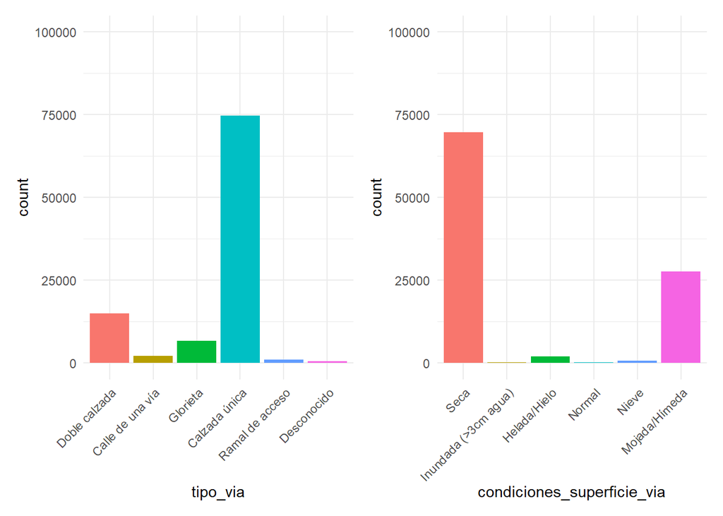

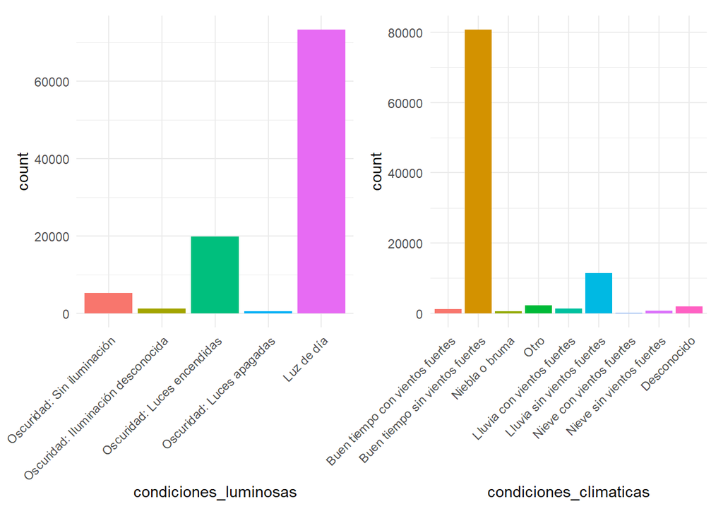

## Gráficos Boxplot

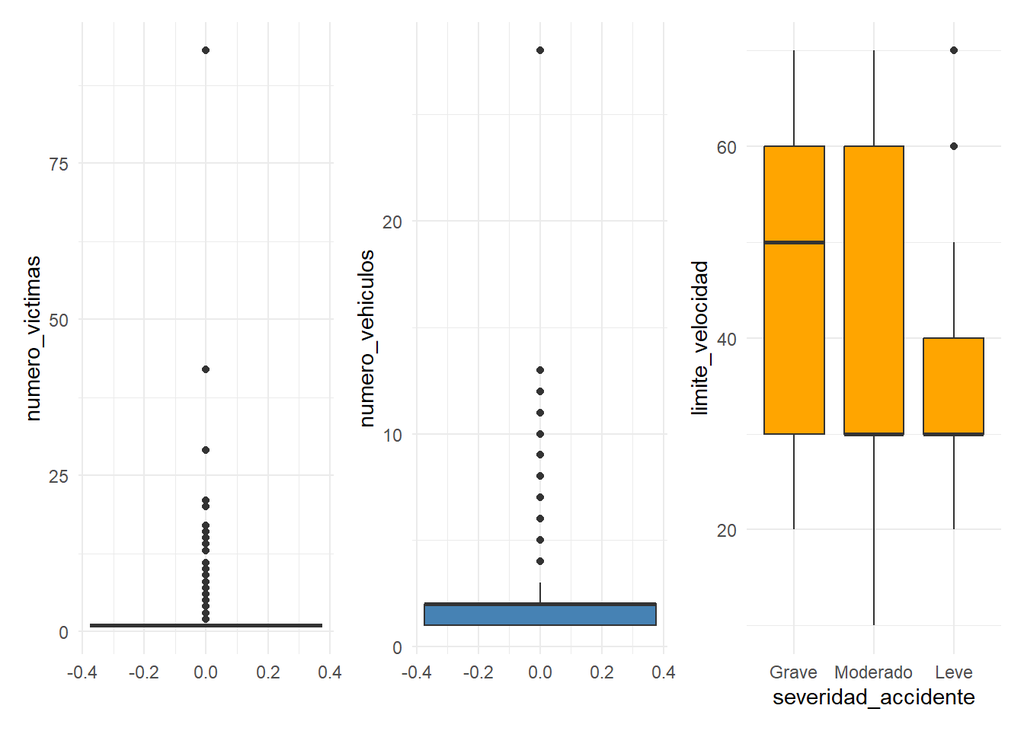

Distribución de Outliers

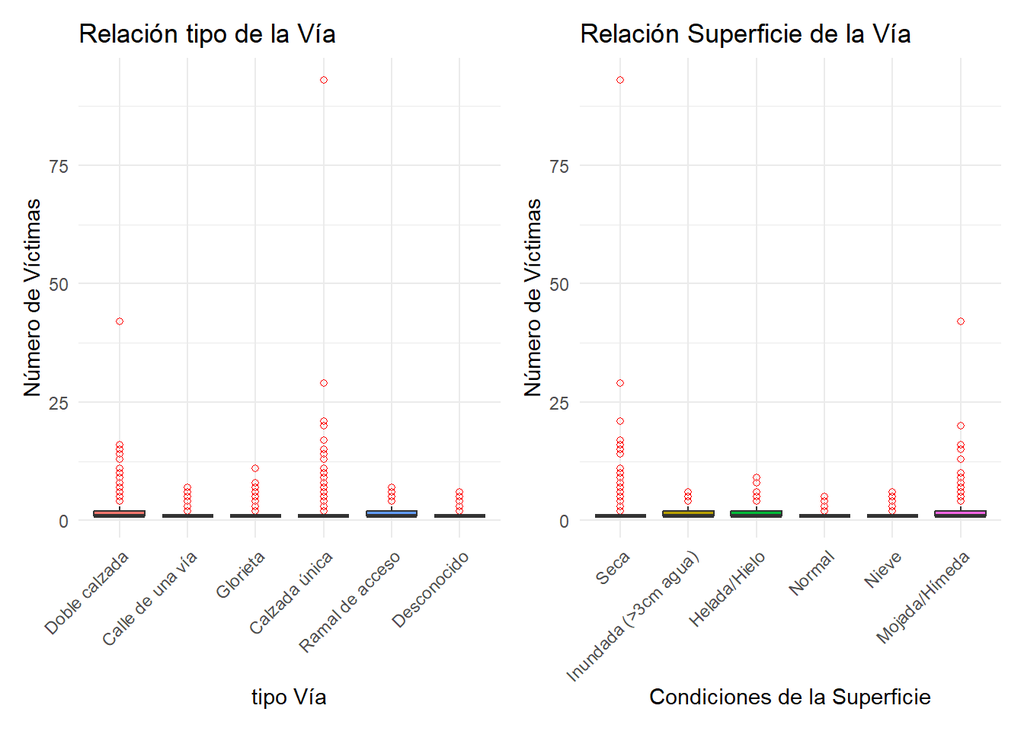

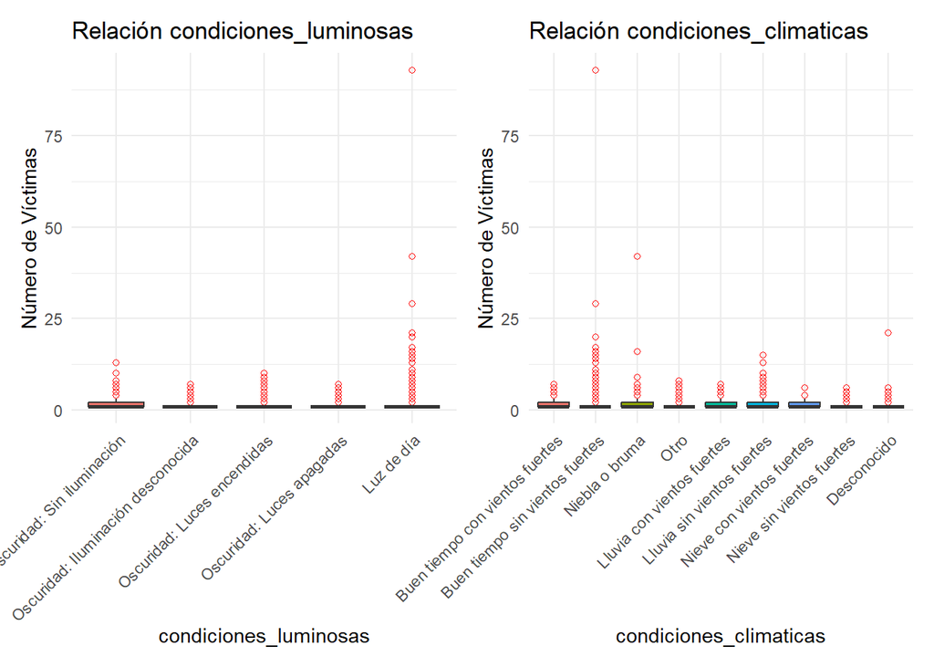

# Modelado GLM

## Modelo Poisson

Se ajusta un modelo inicial asumiendo para la variable respuesta una distribución de Poisson de la siguiente manera:

$$log(Y_i) = \beta_{0} + \beta_{1} \cdot X_{1} + \beta_{2} \cdot X_{2} +
\beta_{3} \cdot X_{3} ... + \beta_{p} \cdot X_{p}$$

Se utiliza el método de selección **stepAIC()** ajustando un modelo GLM con todas las variables explicativas, para observar los resultados del modelo. A continuación dichos resultados

| Observations | 100000 |
| --- | --- |
| Dependent variable | numero_victimas |
| Type | Generalized linear model |
| Family | poisson |
| Link | log |

| χ²(31) | 3774.85 |
| --- | --- |
| p | 0.00 |
| Pseudo-R² (Cragg-Uhler) | 0.04 |
| Pseudo-R² (McFadden) | 0.01 |
| AIC | 248438.50 |
| BIC | 248742.91 |

|  | exp(Est.) | 2.5% | 97.5% | z val. | p |
| --- | --- | --- | --- | --- | --- |
| (Intercept) | 1.12 | 0.96 | 1.30 | 1.44 | 0.15 |
| numero_vehiculos | 1.16 | 1.15 | 1.17 | 54.20 | 0.00 |
| limite_velocidad | 1.00 | 1.00 | 1.00 | 12.15 | 0.00 |
| tipo_viaCalle de una vía | 0.96 | 0.92 | 1.00 | -1.87 | 0.06 |
| tipo_viaGlorieta | 0.93 | 0.91 | 0.96 | -5.06 | 0.00 |
| tipo_viaCalzada única | 1.01 | 0.99 | 1.02 | 0.89 | 0.37 |
| tipo_viaRamal de acceso | 0.97 | 0.92 | 1.02 | -1.14 | 0.26 |
| tipo_viaDesconocido | 1.00 | 0.93 | 1.09 | 0.11 | 0.92 |
| control_interseccionSemaforo automatico | 1.10 | 0.96 | 1.25 | 1.38 | 0.17 |
| control_interseccionCeda el paso o sin control | 1.03 | 0.90 | 1.18 | 0.46 | 0.65 |
| control_interseccionNinguno | 1.03 | 0.91 | 1.18 | 0.48 | 0.63 |
| control_interseccionSeñal de Pare | 1.14 | 0.98 | 1.32 | 1.71 | 0.09 |
| condiciones_luminosasOscuridad: Iluminación desconocida | 0.94 | 0.89 | 0.99 | -2.21 | 0.03 |
| condiciones_luminosasOscuridad: Luces encendidas | 0.98 | 0.95 | 1.01 | -1.55 | 0.12 |
| condiciones_luminosasOscuridad: Luces apagadas | 0.92 | 0.85 | 1.00 | -1.90 | 0.06 |
| condiciones_luminosasLuz de día | 0.94 | 0.92 | 0.96 | -4.85 | 0.00 |
| condiciones_climaticasBuen tiempo sin vientos fuertes | 0.99 | 0.95 | 1.04 | -0.27 | 0.79 |
| condiciones_climaticasNiebla o bruma | 0.93 | 0.85 | 1.01 | -1.75 | 0.08 |
| condiciones_climaticasOtro | 0.96 | 0.90 | 1.02 | -1.34 | 0.18 |
| condiciones_climaticasLluvia con vientos fuertes | 0.95 | 0.89 | 1.02 | -1.39 | 0.17 |
| condiciones_climaticasLluvia sin vientos fuertes | 1.00 | 0.95 | 1.05 | -0.10 | 0.92 |
| condiciones_climaticasNieve con vientos fuertes | 0.97 | 0.82 | 1.16 | -0.29 | 0.77 |
| condiciones_climaticasNieve sin vientos fuertes | 0.92 | 0.84 | 1.02 | -1.58 | 0.11 |
| condiciones_climaticasDesconocido | 0.93 | 0.87 | 0.99 | -2.13 | 0.03 |
| condiciones_superficie_viaInundada (>3cm agua) | 1.10 | 0.95 | 1.28 | 1.31 | 0.19 |
| condiciones_superficie_viaHelada/Hielo | 1.05 | 1.01 | 1.09 | 2.31 | 0.02 |
| condiciones_superficie_viaNormal | 1.04 | 0.89 | 1.22 | 0.52 | 0.60 |
| condiciones_superficie_viaNieve | 1.06 | 0.97 | 1.16 | 1.23 | 0.22 |
| condiciones_superficie_viaMojada/Hímeda | 1.03 | 1.02 | 1.05 | 4.03 | 0.00 |
| zona_urbana_ruralRural | 1.05 | 1.04 | 1.07 | 6.49 | 0.00 |
| severidad_accidenteModerado | 0.85 | 0.82 | 0.89 | -7.24 | 0.00 |
| severidad_accidenteLeve | 0.77 | 0.74 | 0.81 | -12.18 | 0.00 |

Standard errors: MLE

Se observa que la métrica $Pseudo-R^2 \ \ \text{de McFadden}$ es de un $0.01$ y el $Pseudo-R^2 \ \ \text{de Cragg-Uhlee}$ siendo de $0.04$ confirman que el modelo explica el $4 \%$ de la variabilidad de los datos, esto es gran problema, ya que, se espera que el modelo explique al menos un $50 \%$ de variabilidad, por ende, para confirmar, evaluaremos la prueba de sobre-dispersión

```r
## Prueba de sobre dispersión
deviance(mod)/summary(mod)$df[2]
```

```
## [1] 0.3007461
```

El resultado nos indica que este valor esta muy lejos de llegar a ser 1, por ende, el modelo tiende a sufrir infra-dispersión y es algo muy infrecuente de encontrar, casi siempre es la sobre dispersión el problema, por ende, al realizar inferencia sobre el modelo podríamos dar análisis erróneos, tal es así que para manejar este problema, se empleara un modelo Quassi-Poisson, ya que maneja tanto:

$$\phi < 1 \ \ \text{o} \ \ \phi >
1$$

## Modelo Quasipoisson

Dado que el parámetro de dispersión puede ser diferente de 1, ajustamos un modelo Quasipoisson.

| Observations | 100000 |
| --- | --- |
| Dependent variable | numero_victimas |
| Type | Generalized linear model |
| Family | quasipoisson |
| Link | log |

| χ²(31) | 3774.85 |
| --- | --- |
| p | 0.00 |
| Pseudo-R² (Cragg-Uhler) | 0.04 |
| Pseudo-R² (McFadden) | 0.01 |
| AIC | NA |
| BIC | NA |

|  | exp(Est.) | 2.5% | 97.5% | t val. | p |
| --- | --- | --- | --- | --- | --- |
| (Intercept) | 1.12 | 1.01 | 1.24 | 2.15 | 0.03 |
| numero_vehiculos | 1.16 | 1.16 | 1.16 | 80.68 | 0.00 |
| limite_velocidad | 1.00 | 1.00 | 1.00 | 18.09 | 0.00 |
| tipo_viaCalle de una vía | 0.96 | 0.93 | 0.99 | -2.78 | 0.01 |
| tipo_viaGlorieta | 0.93 | 0.92 | 0.95 | -7.54 | 0.00 |
| tipo_viaCalzada única | 1.01 | 1.00 | 1.02 | 1.33 | 0.18 |
| tipo_viaRamal de acceso | 0.97 | 0.94 | 1.00 | -1.69 | 0.09 |
| tipo_viaDesconocido | 1.00 | 0.95 | 1.06 | 0.16 | 0.87 |
| control_interseccionSemaforo automatico | 1.10 | 1.00 | 1.20 | 2.05 | 0.04 |
| control_interseccionCeda el paso o sin control | 1.03 | 0.94 | 1.13 | 0.68 | 0.50 |
| control_interseccionNinguno | 1.03 | 0.95 | 1.13 | 0.71 | 0.48 |
| control_interseccionSeñal de Pare | 1.14 | 1.03 | 1.25 | 2.54 | 0.01 |
| condiciones_luminosasOscuridad: Iluminación desconocida | 0.94 | 0.90 | 0.97 | -3.29 | 0.00 |
| condiciones_luminosasOscuridad: Luces encendidas | 0.98 | 0.96 | 1.00 | -2.31 | 0.02 |
| condiciones_luminosasOscuridad: Luces apagadas | 0.92 | 0.87 | 0.98 | -2.83 | 0.00 |
| condiciones_luminosasLuz de día | 0.94 | 0.93 | 0.96 | -7.22 | 0.00 |
| condiciones_climaticasBuen tiempo sin vientos fuertes | 0.99 | 0.96 | 1.03 | -0.40 | 0.69 |
| condiciones_climaticasNiebla o bruma | 0.93 | 0.87 | 0.98 | -2.61 | 0.01 |
| condiciones_climaticasOtro | 0.96 | 0.92 | 1.00 | -2.00 | 0.05 |
| condiciones_climaticasLluvia con vientos fuertes | 0.95 | 0.91 | 1.00 | -2.06 | 0.04 |
| condiciones_climaticasLluvia sin vientos fuertes | 1.00 | 0.96 | 1.03 | -0.15 | 0.88 |
| condiciones_climaticasNieve con vientos fuertes | 0.97 | 0.87 | 1.09 | -0.44 | 0.66 |
| condiciones_climaticasNieve sin vientos fuertes | 0.92 | 0.87 | 0.99 | -2.35 | 0.02 |
| condiciones_climaticasDesconocido | 0.93 | 0.89 | 0.97 | -3.16 | 0.00 |
| condiciones_superficie_viaInundada (>3cm agua) | 1.10 | 1.00 | 1.22 | 1.96 | 0.05 |
| condiciones_superficie_viaHelada/Hielo | 1.05 | 1.02 | 1.08 | 3.45 | 0.00 |
| condiciones_superficie_viaNormal | 1.04 | 0.94 | 1.16 | 0.78 | 0.44 |
| condiciones_superficie_viaNieve | 1.06 | 1.00 | 1.13 | 1.83 | 0.07 |
| condiciones_superficie_viaMojada/Hímeda | 1.03 | 1.02 | 1.04 | 6.00 | 0.00 |
| zona_urbana_ruralRural | 1.05 | 1.04 | 1.07 | 9.66 | 0.00 |
| severidad_accidenteModerado | 0.85 | 0.83 | 0.88 | -10.77 | 0.00 |
| severidad_accidenteLeve | 0.77 | 0.75 | 0.79 | -18.13 | 0.00 |

Standard errors: MLE

Observamos que la estimación del parámetro de infra-dispersión es $\phi=0.4513$ entonces, la varianza observada es menor que la media. como consecuencia los errores típicos asociados a los coeficientes del modelo han sido multiplicados por $\sqrt{0.42513} = 0.6718$ , y así, esté ajuste produce intervalos de confianza más estrechos y p-valores más pequeños, haciendo que los parámetros tiendan a ser más significativos como tambien los IC más que en el modelo de regresión Poisson. ## Supuestos

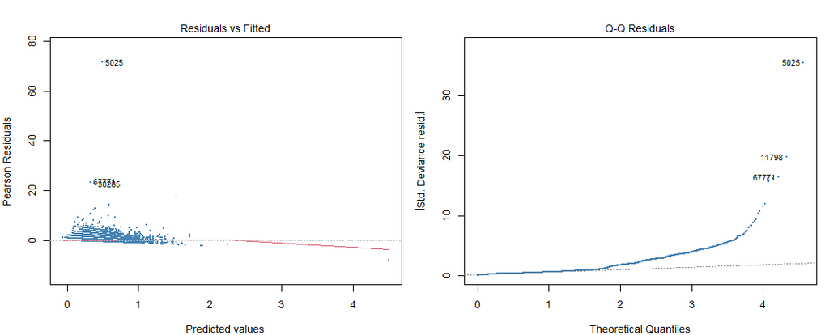

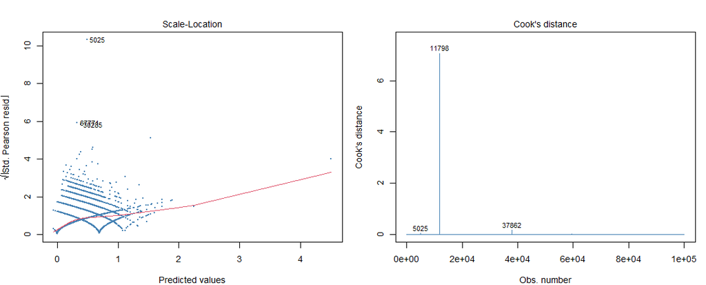

1. Se observa que para el primer gráfico de residuales vs ajustados, los puntos no tienen un patrón muy plasmado, además, casi todos estan posicionados cerca de cero a pesar de varios outliers presentes.
2. El Quantil Quantil, nos arroja que aunque al principio sigue buen ajuste, a medida que se va alejando, la distribución de la variable presenta sesgo, teniendo colas pesadas a derecha y datos atípicos.

3.La eliminación de posibles datos que como consecuencia realizan leverage o outliers problemáticos al modelo, no se puede utilizar este método ya que se deberá indagar mas a fondo para su posible omisión, por consiguiente, se trabajaran con ellos, ya que, son registros verídicos.

## Linealidad de predictores

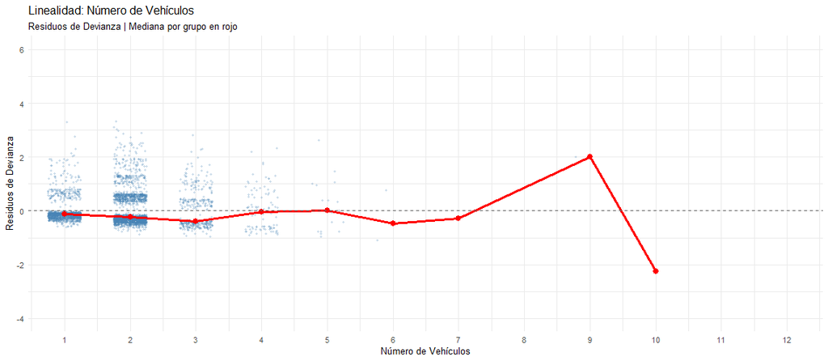

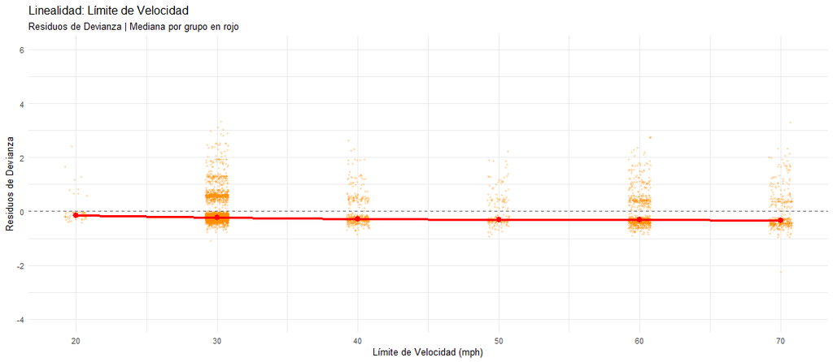

Se observa que los datos siguen una relación cercana a cero aunque para la variable numero de vehículos, se presenta un desequilibrio de la recta y aumenta o disminuye, esto pasa por que en ciertos conteos o número de victimas los registros son muy pocos. ## Equidisperción

```r
## Prueba de sobre dispersión
deviance(mod_Quass)/summary(mod_Quass)$df[2]
```

```
## [1] 0.3007461
```

Como el modelo ya esta ajustado, se considera la probabilidad de sobre infra-dispersión

|  | IRR | SE | z_value | p_valor | CI_low | CI_high |
| --- | --- | --- | --- | --- | --- | --- |
| (Intercept) | 1.1181 | 0.0464 | 2.4043 | 0.0162 | 1.0208 | 1.2246 |
| numero_vehiculos | 1.1602 | 0.0123 | 12.0692 | 0 | 1.1325 | 1.1885 |
| limite_velocidad | 1.0036 | 0.0002 | 16.1595 | 0 | 1.0032 | 1.0041 |
| tipo_viaCalle de una vía | 0.9598 | 0.0128 | -3.1966 | 0.0014 | 0.9359 | 0.9843 |
| tipo_viaGlorieta | 0.933 | 0.0086 | -8.0232 | 0 | 0.9173 | 0.9489 |
| control_interseccionSemaforo automatico | 1.0976 | 0.0329 | 2.8338 | 0.0046 | 1.0291 | 1.1707 |
| control_interseccionSeñal de Pare | 1.1367 | 0.043 | 2.9839 | 0.0028 | 1.045 | 1.2366 |
| condiciones_luminosasOscuridad: Iluminación desconocida | 0.9376 | 0.0186 | -3.4657 | 0.0005 | 0.904 | 0.9724 |
| condiciones_luminosasOscuridad: Luces encendidas | 0.9789 | 0.0105 | -2.0229 | 0.0431 | 0.9589 | 0.9993 |
| condiciones_luminosasOscuridad: Luces apagadas | 0.9215 | 0.0267 | -3.0622 | 0.0022 | 0.8746 | 0.971 |

[output cut: 11 more lines]

Se observa que por cada unidad que aumenta el numero de vehículos, se espera que el numero de victimas en accidentes en vías aumente en un $16.02 \%$, manteniendo las demás variables constantes. Por otra parte, se espera que de igual manera el limite de velocidad aumente en un $0.36 \%$ las posibles victimas fatales y en con secuencia podremos interpretar de igual manera que los fallecimientos aumentan en las zonas Rurales un $5.41 \%$, en los controles de intersección, específicamente el semáforo automático y señal de pare en un porcentaje del $9.76\%$ y $13.67\%$. Además, las condiciones de la superficies de la vía el porcentaje de Helada/Hielo sera de $4.85\%$, Nieve de $5.89\%$ y Mojada/Húmeda de $3.25\%$.

Es importante mencionar, como tambien por cada unidad que aumenta los predictores (covariables $X$) se presenta una disminución de victimas fatales por accidentes, tales como; las condiciones del tipo de vía **calle a una vía y Glorieta** estas disminuyen el riesgo en un $4.02 \%$ y $6.7 \%$, de igual manera las condiciones a la hora del accidente (oscuridad) en comparación con el nivel “*Sin iluminación*”,para el nivel luces encendidas la disminución de mortalidad es de $2.11 \%$, con luces apagadas en un $7.86\%$ y para luz de día en un $5.84\%$. A su vez, las condiciones climáticas presentan dicho fenómeno, de la cuál, la categoría Lluvia con vientos fuertes con un porcentaje del $4.76\%$, Nieve sin vientos fuertes en un $7.54\%$ y sin dejar a un lado la severidad del accidente, si es moderado esta disminución de victimas fatales será de un porcentaje mayor con $14.8 \%$ y si el accidente es leve de un $22.73 \%$.

## Modelo con Offset

Para dar un enfoque mayor en nuestro análisis, implementamos un modelo agregando un “*offset(número_vehículos)*”, para observar como se comportan las tasas con respecto a la nueva especificación dada.

Utilizamos el número de vehículos como offset para modelar la tasa de víctimas.

| Observations | 100000 |
| --- | --- |
| Dependent variable | numero_victimas |
| Type | Generalized linear model |
| Family | quasipoisson |
| Link | log |

| χ²(22) | 1805.75 |
| --- | --- |
| p | 0.00 |
| Pseudo-R² (Cragg-Uhler) | -0.05 |
| Pseudo-R² (McFadden) | -0.02 |
| AIC | NA |
| BIC | NA |

|  | exp(Est.) | 2.5% | 97.5% | t val. | p |
| --- | --- | --- | --- | --- | --- |
| (Intercept) | 0.92 | 0.83 | 1.03 | -1.46 | 0.14 |
| limite_velocidad | 1.00 | 1.00 | 1.00 | 8.40 | 0.00 |
| tipo_viaCalle de una vía | 1.11 | 1.08 | 1.15 | 6.52 | 0.00 |
| tipo_viaGlorieta | 0.99 | 0.97 | 1.01 | -1.16 | 0.25 |
| tipo_viaCalzada única | 1.08 | 1.06 | 1.09 | 11.62 | 0.00 |
| tipo_viaRamal de acceso | 1.03 | 0.99 | 1.07 | 1.35 | 0.18 |
| tipo_viaDesconocido | 1.11 | 1.05 | 1.18 | 3.60 | 0.00 |
| control_interseccionSemaforo automatico | 1.08 | 0.98 | 1.19 | 1.56 | 0.12 |
| control_interseccionCeda el paso o sin control | 1.00 | 0.91 | 1.10 | 0.04 | 0.97 |
| control_interseccionNinguno | 1.07 | 0.97 | 1.18 | 1.41 | 0.16 |
| control_interseccionSeñal de Pare | 1.07 | 0.96 | 1.19 | 1.22 | 0.22 |
| condiciones_luminosasOscuridad: Iluminación desconocida | 0.87 | 0.84 | 0.91 | -6.52 | 0.00 |
| condiciones_luminosasOscuridad: Luces encendidas | 0.90 | 0.89 | 0.92 | -10.22 | 0.00 |
| condiciones_luminosasOscuridad: Luces apagadas | 0.86 | 0.81 | 0.91 | -4.79 | 0.00 |
| condiciones_luminosasLuz de día | 0.84 | 0.83 | 0.86 | -18.80 | 0.00 |
| condiciones_superficie_viaInundada (>3cm agua) | 1.23 | 1.10 | 1.37 | 3.75 | 0.00 |
| condiciones_superficie_viaHelada/Hielo | 1.12 | 1.09 | 1.15 | 7.85 | 0.00 |
| condiciones_superficie_viaNormal | 1.00 | 0.89 | 1.11 | -0.04 | 0.97 |
| condiciones_superficie_viaNieve | 1.06 | 1.01 | 1.11 | 2.33 | 0.02 |
| condiciones_superficie_viaMojada/Hímeda | 1.03 | 1.02 | 1.04 | 7.14 | 0.00 |
| zona_urbana_ruralRural | 1.04 | 1.03 | 1.05 | 6.59 | 0.00 |
| severidad_accidenteModerado | 0.88 | 0.85 | 0.90 | -8.33 | 0.00 |
| severidad_accidenteLeve | 0.74 | 0.72 | 0.76 | -19.52 | 0.00 |

Standard errors: MLE

```r
## Prueba de sobre dispersión
deviance(off_mod1)/summary(off_mod1)$df[2]
```

```
## [1] 0.3818196
```

|  | IRR | SE | z_value | p_valor | CI_low | CI_high |
| --- | --- | --- | --- | --- | --- | --- |
| limite_velocidad | 1.0018 | 0.0002 | 7.7961 | 0 | 1.0014 | 1.0023 |
| tipo_viaCalle de una vía | 1.11 | 0.0143 | 7.3103 | 0 | 1.0794 | 1.1415 |
| tipo_viaCalzada única | 1.0753 | 0.0071 | 10.2156 | 0 | 1.0605 | 1.0904 |
| tipo_viaDesconocido | 1.1137 | 0.0299 | 3.5979 | 0.0003 | 1.0502 | 1.1809 |
| control_interseccionSemaforo automatico | 1.0799 | 0.0344 | 2.2362 | 0.0253 | 1.0095 | 1.1551 |
| control_interseccionNinguno | 1.0713 | 0.034 | 2.0256 | 0.0428 | 1.0022 | 1.1452 |
| condiciones_luminosasOscuridad: Iluminación desconocida | 0.8714 | 0.0212 | -6.5052 | 0 | 0.836 | 0.9083 |
| condiciones_luminosasOscuridad: Luces encendidas | 0.9028 | 0.0118 | -8.6662 | 0 | 0.8822 | 0.9239 |
| condiciones_luminosasOscuridad: Luces apagadas | 0.8604 | 0.0306 | -4.9108 | 0 | 0.8103 | 0.9136 |
| condiciones_luminosasLuz de día | 0.8443 | 0.011 | -15.32 | 0 | 0.8262 | 0.8628 |

[output cut: 7 more lines]

Además, la condiciones luminosas por número de vehículos, se evidencia que en condiciones de oscuridad la tasa de victimas disminuye en un $9.72 \%$ cuando estas están encendidas en comparación con la categoría sin iluminación, de igual manera en un $13.96 \%$ con luces apagadas y en un $15.57 \%$ cuando se transita de día. Cabe destacar que el nivel de iluminación desconocida con un $12.86\%$ de disminución, puede presentar problemas de registro, accidentes en condiciones irregulares o contextos más caóticos.

Por otra parte, las condiciones en la superficie de la vía por número de vehículos, presenta una tasa en aumento de un $22.70\%$ para vías inundadas, $11.89\%$ para vías Heladas/Hielo, $5.98\%$ vías con nieve y $3.28\%$ en vías Mojada/Húmeda en comparación con la categoría de referencia “*Seca*”.

Adicionalmente, el tipo de zona por número de vehículos presento que en comparación con la zona urbana, la zona rural presenta un amento de víctimas en un $3.95\%$.

finalmente, la severidad de del accidente por numero de vehículos tomando como categoría de referencia el nivel “GRAVE”, se identifico que los accidentes Moderados tienden a disminuir en un $12.47 \%$ y si es accidente leve en un $25.86% \%$.

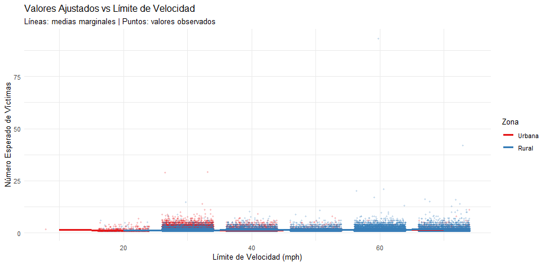

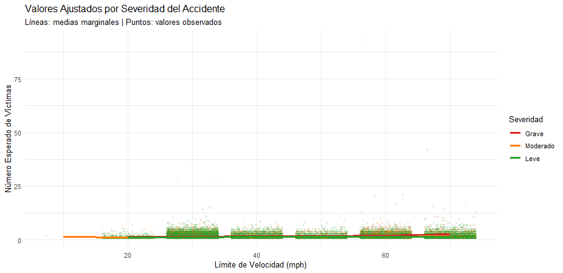

# Conclusiones

Los resultados obtenidos permiten concluir que mediante el modelo Quassi-Poisson con ofsset() por número de vehículos, hubieron varias variables significativas que podrían explicar ciertas causalidades para el numero de víctimas, además de factores que en cierta medida son importantes a la hora de realizar un viaje programado.

¿Existen diferencias significativas en el número de víctimas entre accidentes en zonas urbanas y rurales?, en este caso, los resultados arrojaron que en casi un $4\%$ el numero de victimas aumenta si se transita en zonas rurales.

En conjunto, estos hallazgos evidencian que el número de víctimas por vehículo en un accidente no depende únicamente del número de vehículos involucrados, sino que está fuertemente influenciado por factores contextuales como el tipo de vía, la iluminación, el estado de la superficie, la zona y la severidad del siniestro. Estos resultados pueden ser de utilidad para el diseño de políticas públicas orientadas a la prevención de accidentes y la mitigación de sus consecuencias.

El análisis realizado fue de carácter inferencial. Si bien el P-Seudo $R^2$ obtenido es relativamente bajo, esto es esperable en modelos de conteo aplicados a fenómenos de alta variabilidad como los accidentes de tráfico, donde intervienen múltiples factores no siempre medibles. Por esta razón, el modelo no debe interpretarse como una herramienta de predicción precisa, sino como un instrumento para identificar asociaciones significativas entre las variables. Para futuros análisis, se recomienda incorporar variables adicionales de mayor poder explicativo, como condiciones del conductor, hora exacta del accidente o densidad vehicular.